# Chapter 3: Theories, hypotheses, and comparisons

# Reminders

- Workbook homework due on Thursday
- Pilot survey is in the works, expect to see a link next week. Then you’ll need to take the survey yourself and provide feedback on the questions.
  - I’m trying to consolidate, so you might not see your exact question, but you will hopefully see something that approximates it.

# Goals

- Begin looking at relationships between variables
- Theoretical Arguments and Hypotheses
- Elements of a good theory
- Writing good hypotheses
- Testing Hypotheses

(material here comes mostly from Chapter 3 of your textbook)

# The goals of research

- Describing: making generalization about the world
- Predicting: generating expectations about what will happen in the future
- Explaining: explaining why things are related.

Explanation is often the toughest to achieve, but also the most desirable because it allows us to do things like make changes to reach a desired outcome.

## “Why” questions

- “Why questions”
  - Why do some eligible voters fail to turn out on election day?
  - What explains variation in gun policies across U.S. states?
  - Why did communist revolutions happen in China and Russia but not Europe or the United States?

# Theories

> “a logically interconnected set of propositions from which empirical uniformities can be derived” – **Robert K Merton**

Theories are explanations, assumptions, claims and narratives that provide a set of expectations that link a cause to an effect.

Purely descriptive or predictive analyses don’t necessarily require a theory, but its a key component of explanatory research.

## Theoretical Scope

Theories vary in their scope:

- Early sociologists like Marx, Durkheim, Weber attempted to develop all-encompassing “laws” of political/social/historical change. These are sometimes called “grand theories”
- Contemporary social sciences are less ambitious, and so its more common to propose “middle-range” theories that seek to explain a smaller number regularities in one area.
  - However, they may draw on “grand theories” either implicitly or explicitly.

## Paths to Modernity

What explains differences in the “path to modernity” across different countries during the 20th century?

- Free markets/Democracy in the U.S. and England
- Fascism in Germany and Japan
- Communism in Russia and China

## Paths to Modernity

Barrington Moore: Classes have unique and conflicting interests. Conflicts over these interests come to the forefront during industrialization. The outcomes of these class conflicts shape the political and economic system.

- Fascist states emerge when the landed aristocracy wins
- Communist states emerge when the peasant class wins
- Democracies emerge when the bourgeois (middle class) wins.

[figure not shown]

## Paths to Modernity

- Moore’s theory borrows assumptions from a (sociological) Marxist grand theory about class conflict
- He “tests” it by showing how it fits the selected cases.
- It can be used and refined to generate a set of empirical expectations about what factors should matter for democratization. For instance, we might expect:
  - States with larger agricultural sectors during industrialization to be less democratic today (compared to states with smaller agricultural sectors)
  - States with higher literacy rates during industrialization to be more democratic (compared to states with lower literacy rates)

# Good Theories

- (For our purposes) theories are statements about cause and effect and causal mechanisms—If X happens, then Y will follow as a result because….
- Good theories clearly identify:
  - A **dependent variable(s):** the outcome to be explained
  - One or more **independent variables:** the causal factors that determine the DV.
  - A causal mechanism that links these two things.
  - An expectation about the direction of the effect (positive, negative, something more complex)
- Most social science theories are probabilistic instead of deterministic. So we’ll speak in terms of more/less likely or higher/lower.
- Good theories should generate expectations that can be empirically tested (even if the theory itself can’t be tested)

## Theories: survey answers

What explains inconsistent answers to survey questions?

- Asking the same people the same questions a few months apart yields surprisingly unpredictable results.
- Small changes in question wording, ordering of choices, or survey context cause big changes in outcomes

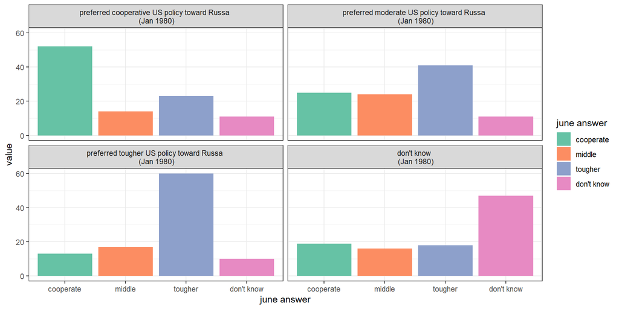

Data from the 1980 ANES panel survey (reproduced from Zaller 1992)

### Theories: RAS model

- Recieve-Accept-Sample model (Zaller)
  - Receive: People hear persuasive messages
  - Accept: They accept some of these and reject others depending on their predispositions.
  - Sample: When they answer a survey, they “sample” from the top-of-mind considerations.
- **outcome:** attitude stability, attitudes
- **causes:** the volume and clarity of messages (especially from elites)
- (some) Expectations:
  - More engaged people are more persuadable when partisan cues are low
  - People with low engagement/knowledge will develop more consistent answers issues are highly salient

## Theories: voting

Why do people vote?

- Since politicians generally offer *public goods*, you can enjoy the benefits of your preferred candidate winning even if you don’t vote
- Since voting has costs (even though they’re small) free riding can be preferable to actually turning out if the costs outweigh the benefits.

### Theories: voting

**Pivotal voting**

- **Claim:** people vote because they expect to sway the election
- **If this is true, then:**
  - Turnout should be higher in close elections
  - Turnout should be higher when the electorate is small
  - Turnout will be higher in PR systems where one vote matters more.

**Expressive voting model**

- **Claim:** people vote to enjoy the *expressive* benefits
- **If this is true then:**
  - People with more extreme beliefs will be more likely to vote
  - Closeness or the size of the electorate shouldn’t matter much

Its unlikely that either theory is *entirely* true, but both can be used to generate expectations and productive debate over the relative weight of the evidence favoring one explanation vs. another.

## Assessing Theories

- Theories require simplified representations of a complex reality
- Utility, not “truth”: theoretical models invariably contain **assumptions** and they’re probably violated in practice.

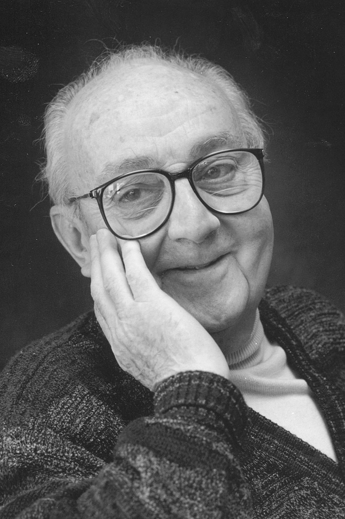

George Box: “All models are wrong, but some are useful”

### Assessing Theories

- Consistency
  - Is our theory internally consistent? Does it have a clear logic?
- Empirical accuracy
  - Do the theories help us understand the world?
  - Are observed realities consistent with the expectations our theory generates?
  - Can we use a theory to make useful predictions about future events?
  - Can the theory adapt in the face of inconsistent findings? (this will happen!)
- Theories may be more or less useful in certain contexts
  - There’s stronger evidence for the pivotal voter model in small elections and referenda, but other models do a better job explaining national level turnout

# Hypotheses

- Theories give causal explanations for why something effects something else
- Hypotheses are specific testable implications generated by that theory.
  - Theory: people vote because of expressive benefits
  - Hypothesis: people with more extreme views will be more likely to turn out.

## Hypotheses

Components:

- Unit of analysis
- Dependent variable
- Independent variable
- Direction of the predicted relationship

Good hypotheses inevitably involve comparative language (higher/lower/more/less/increase/decrease/better/worse)

## Hypothesis Template

In a comparison of [*unit of analysis*], those having [*one value on the independent variable*] will be [*more/less*] likely to have [*one value on the dependent variable*] than those having a [*different value on the independent variable*].

## Hypothesis Template

In a comparison of [voters], those having [stronger political views] will be more likely to have [a higher likelihood of turnout] than those having a [weaker views].

- **Unit of analysis:** voters
- **IV:** strength of political views
- **DV:** turnout
- **Relationship:** strength increases turnout

## Hypothesis Template

In a comparison of [states], those having [a larger middle class during industrialization] will be more likely to have [democracy] than those having a [a smaller middle class].

- **Unit of analysis:** states
- **IV:** size of the middle class
- **DV:** democracy
- **Relationship:** middle class increases likelihood of democracy

## Hypothesis Template

In a comparison of [survey respondents], those having [higher levels of attention to politics] will be more likely to have [consistent responses] than those having a [lower levels of attention to politics].

- **Unit of analysis:** Survey respondents
- **IV:** level of attention
- **DV:** response consistency
- **Relationship:** attention increases consistency

## Complex Relationships

Good hypotheses may suggest a more complex set of relationships than just “positive/negative”. They could propose conditional/interactive/curvilinear relationships as well.

The “oil curse”

> In a comparison of [countries], those having [higher levels of GDP] will be [more likely to be democratic] compared to [countries with lower GDP], [**however,** this relationship will not hold for countries that get rich from oil exports.]

Retrospective voting:

> In a comparison of [voters], those having [lower levels of attention to politics] will be [more likely to vote for the incumbent when the economy is doing well]. Those having [higher levels of attention to politics] will be [more likely to vote based on policy preferences regardless of the state of the economy]

## Bad hypotheses

- The main determinant of war is the distribution of power in the international system.
- In comparing individuals, annual income and the level of education are related.
- Democracies are peaceful. In comparing individuals, some people are more likely to favor the death penalty than others.

# Next

- Testing hypotheses by making comparisons
- Graphing and describing relationships

# Testing Hypotheses

# Cross tabulation

Assuming we have a categorical independent variable (IV) and a categorical dependent variable (DV):

| iv | dv |
| --- | --- |
| HIGH | No |
| HIGH | No |
| LOW | No |
| HIGH | Yes |
| HIGH | Yes |
| HIGH | Yes |
| HIGH | Yes |
| LOW | Yes |
| LOW | Yes |
| LOW | Yes |

## Cross tabulation: Step 1

Start by calculating the number of observations with each value of each category:

| iv | dv |
| --- | --- |
| HIGH | No |
| HIGH | No |
| LOW | No |
| HIGH | Yes |
| HIGH | Yes |
| HIGH | Yes |
| HIGH | Yes |
| LOW | Yes |
| LOW | Yes |
| LOW | Yes |

| dv | iv LOW | iv HIGH |
| --- | --- | --- |
| No | 1 | 2 |
| Yes | 3 | 4 |
| Total | 4 | 6 |

## Cross tabulation: Step 2

Then, calculate the proportion/percentage of observations among each value of the IV.

If the independent variable is in the **columns**, then the columns should sum to 100%.

If the independent variable is in the **rows**, then the rows should sum to 100%.

| dv | iv LOW | iv HIGH |
| --- | --- | --- |
| No | 1 | 2 |
| Yes | 3 | 4 |
| Total | 4 | 6 |

| dv | iv LOW | iv HIGH |
| --- | --- | --- |
| No | 1 (25%) | 2 (33%) |
| Yes | 3 (75%) | 4 (67%) |
| Total | 4 | 6 |

## Cross tabulation: interpretation

Look at what happens to the DV at different values of the IV. If your variables are ordinal, you should be able to identify a **direction** of the effect.

The proportion of “Yes” values decreases as the IV goes from lower to higher, so this is a negative or *inverse* relationship.

| dv | iv LOW | iv HIGH |
| --- | --- | --- |
| No | 1 (25%) | 2 (33%) |
| Yes | 3 (75%) | 4 (67%) |
| Total | 4 | 6 |

Using a bar graph or line graph can make these relationships easier to spot:

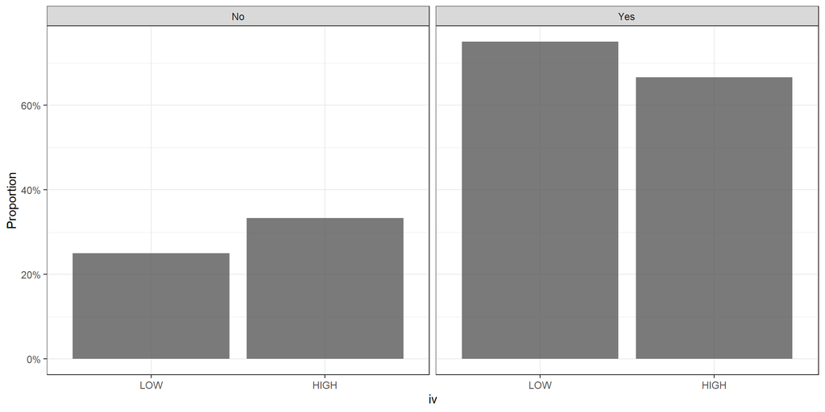

## Cross tabulation: notes

- Key rule: always calculate percentages or proportions by categories of the **independent variable**.
  - This allows you to compare groups that are different sizes.
- If one or both variables are interval-level, you can bin them in order to use them in a cross tab. For instance, you could separate an interval like into a series of age ranges.

## Cross tabulation: example

Hypothesis: in a comparison of individuals, **independents** are less likely to turn out to vote compared to people who support one party or another.

How should I calculate proportions here?

Voter Turnout in 2020 by party ID

| turnout2020 | Party ID Democrat | Party ID Independent | Party ID Republican |
| --- | --- | --- | --- |
| 0. Did not vote | 335 | 316 | 382 |
| 1. Voted | 3160 | 560 | 2714 |

## Cross tabulation: example

Are these results generally consistent with my hypothesis?

Voter Turnout in 2020 by party ID

| turnout2020 | Party ID Democrat | Party ID Independent | Party ID Republican |
| --- | --- | --- | --- |
| 0. Did not vote | 335 (10%) | 316 (36%) | 382 (12%) |
| 1. Voted | 3160 (90%) | 560 (64%) | 2714 (88%) |

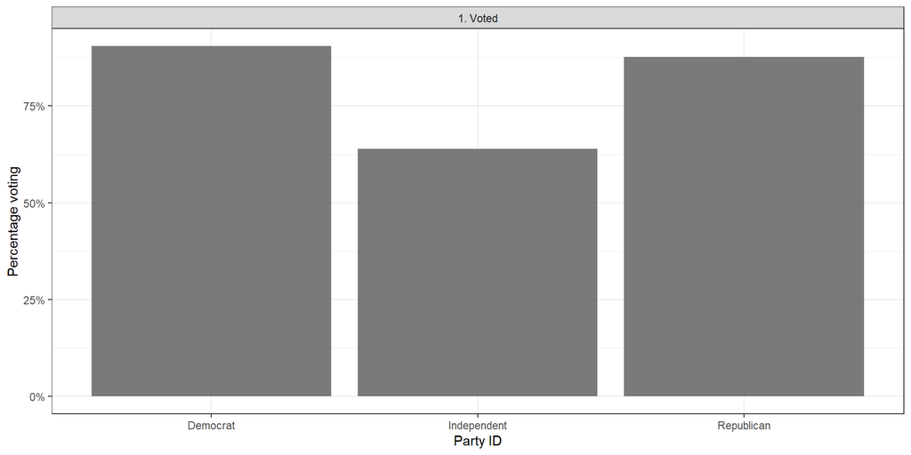

If we think of party ID as an ordered variable, this is a curvilinear relationship.

## Row/Column percentages

What happens if I calculate % among the values of the DV?

Here’s the relationship between education and voter turnout with % calculated on education level:

Voter Turnout in 2020 by highest level of education completed

| turnout2020 | Education 1. Less than high school credential | Education 2. High school credential | Education 3. Some post-high school, no bachelor's degree | Education 4. Bachelor's degree | Education 5. Graduate degree |
| --- | --- | --- | --- | --- | --- |
| 0. Did not vote | 130 (41%) | 286 (24%) | 380 (15%) | 135 (7%) | 91 (6%) |
| 1. Voted | 185 (59%) | 883 (76%) | 2148 (85%) | 1749 (93%) | 1388 (94%) |

Note:  
Column % in parentheses

The results suggest a positive or *direct* relationship: as education increases, so does the % turnout.

## Row/Column percentages

What happens if I calculate % among the values of the DV?

Here’s the relationship between education and voter turnout with % calculated across voter turnout

Voter Turnout in 2020 by highest level of education completed

| turnout2020 | Education 1. Less than high school credential | Education 2. High school credential | Education 3. Some post-high school, no bachelor's degree | Education 4. Bachelor's degree | Education 5. Graduate degree |
| --- | --- | --- | --- | --- | --- |
| 0. Did not vote | 130 (13%) | 286 (28%) | 380 (37%) | 135 (13%) | 91 (9%) |
| 1. Voted | 185 (3%) | 883 (14%) | 2148 (34%) | 1749 (28%) | 1388 (22%) |

Note:  
Row % in parentheses

Here, the results can give the misleading impression that there’s a curvilinear relationship: turnout drops off for Bachelor’s Degrees and above.

## Row/Column percentages

Either of these tables might be a valid way to look at these data, but they answer slightly different questions:

- If I want to compare turnout at different levels of education, then I need to calculate % turnout among people with different levels of education.
- If I want to compare education among voters and non-voters, then I need to calculate % education among people who voted and didn’t vote.
- Which variable is the IV or DV is sometimes a theoretical question, but in this case its unlikely that voting is **causing** people to become more educated, so it probably doesn’t make sense to calculate percentages by voting vs. non-voting.

# Mean Comparison

When we have interval level *outcome* and a categorical independent variable, we can group each observation by values of the IV and then calculate the mean across each group.

For instance I want to examine the relationship between national wealth and carbon emissions. My hypothesis is that wealthier nations will have more emissions compared to poorer nations.

| country | gdp.percap.5cat | co2.percap |
| --- | --- | --- |
| Afghanistan | 1. $3k or less | 0.281803 |
| Albania | 3. $10k to $25k | 1.936486 |
| Algeria | 3. $10k to $25k | 3.988271 |
| Angola | 2. $3k to $10k | 1.194668 |
| Argentina | 3. $10k to $25k | 3.995881 |
| Armenia | 3. $10k to $25k | 2.030401 |
| Australia | 5. $45k or more | 16.308205 |
| Austria | 5. $45k or more | 7.648816 |
| Azerbaijan | 3. $10k to $25k | 3.962984 |
| Bahrain | 5. $45k or more | 20.934996 |

## Mean Comparison

GDP data has been grouped into five categories, so now I just need to calculate the average of CO2 emissions within each group of the ordinal IV:

| GDP Per capita range | CO2 emissions per capita |
| --- | --- |
| 1. $3k or less | 0.3128312 |
| 2. $3k to $10k | 1.2680574 |
| 3. $10k to $25k | 4.4065669 |
| 4. $25k to $45k | 8.0307610 |
| 5. $45k or more | 12.3134306 |

Is this generally consistent with expectations?

## Mean Comparison

Here again, the relationship can be easier to conceptualize if we plot it.

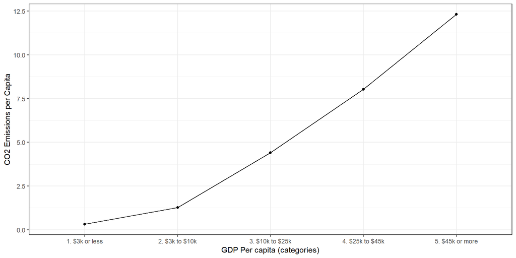

## Curvilinear Relationships

A relationship like this will rarely be perfectly straight, so “linearity” and “curvilinearity” are partly a matter of degree, but there are some cases where there is a clear “U” shape to the relationship:

| iv | dv |
| --- | --- |
| 1. Extremely liberal | 6.314 |
| 2. Liberal | 5.685 |
| 3. Slightly liberal | 5.001 |
| 4. Moderate; middle of the road | 4.651 |
| 5. Slightly conservative | 4.636 |
| 6. Conservative | 4.974 |
| 7. Extremely conservative | 5.363 |

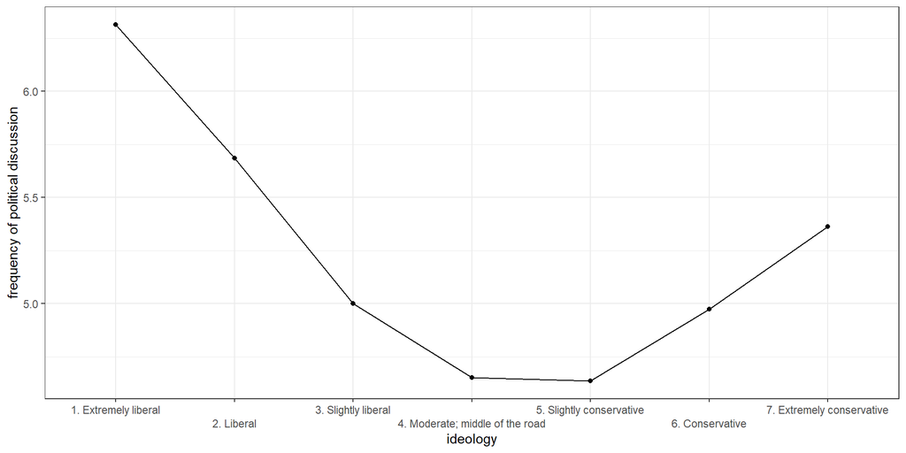